# Part_II_slide_deck_template

## Dataset Overview

The Ford GoBike System Data is a set of informations about individual rides made in a bike-sharing system covering the greater San Francisco Bay area.

```python
# import all packages and set plots to be embedded inline
import numpy as np
import pandas as pd
import matplotlib.pyplot as plt
import seaborn as sb

%matplotlib inline

# suppress warnings from final output
import warnings
warnings.simplefilter("ignore")
```

```python
# load in the dataset into a pandas dataframe
df = pd.read_csv('./clean.csv')
df.info()
```

```
<class 'pandas.core.frame.DataFrame'>
RangeIndex: 174952 entries, 0 to 174951
Data columns (total 28 columns):
 #   Column                   Non-Null Count   Dtype
---  ------                   --------------   -----
 0   duration_sec             174952 non-null  int64
 1   start_time               174952 non-null  object
 2   start_station_id         174952 non-null  float64
 3   start_station_name       174952 non-null  object
 4   start_station_latitude   174952 non-null  float64
 5   start_station_longitude  174952 non-null  float64
 6   start_date               174952 non-null  object
 7   start_day                174952 non-null  object
 8   start_month              174952 non-null  object
 9   start_periode_of_day     174952 non-null  object
```

[output cut: 20 more lines]

## Distribution of member gender

We can see that member gender is higly dominated by Male.

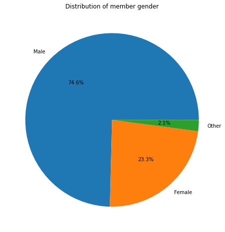

```python
plt.figure(figsize=[10, 8])
plt.pie(x=df.member_gender.value_counts(),
        labels=df.member_gender.value_counts().index, autopct='%1.1f%%',)
plt.title('Distribution of member gender');
```

## Distributiion of user type

User type is hightly dominated by subscribers

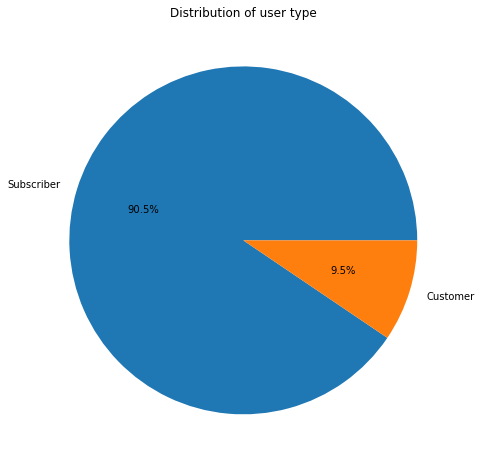

```python
plt.figure(figsize=[10, 8])
plt.pie(x=df.user_type.value_counts(),
        labels=df.user_type.value_counts().index, autopct='%1.1f%%',)
plt.title('Distribution of user type');
```

## Distribution of start periode of the day

Bike trips mostly start in afternoon

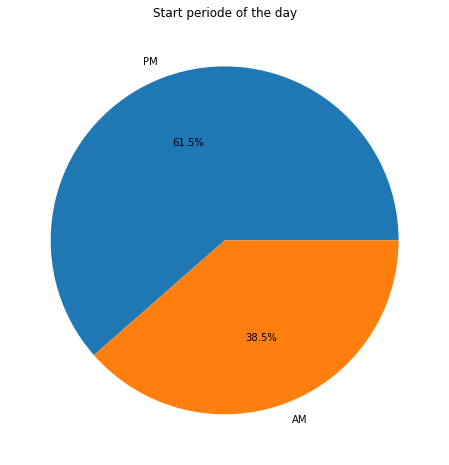

```python
plt.figure(figsize=[10, 8])
plt.pie(x=df.start_periode_of_day.value_counts(),
        labels=df.start_periode_of_day.value_counts().index, autopct='%1.1f%%',);
plt.title('Start periode of the day');
```

## Distribution of days in the week

Most of the bike trip start on tuesday, wednesday and thursday.

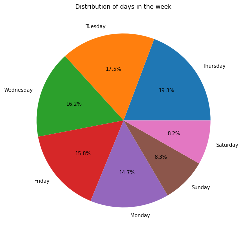

```python
plt.figure(figsize=[10, 8])
plt.pie(x=df.start_day.value_counts(),
        labels=df.start_day.value_counts().index, autopct='%1.1f%%',)
plt.title('Distribution of days in the week');
```

## Influence of age on duration

Teenagers and adults ride longuer than elders

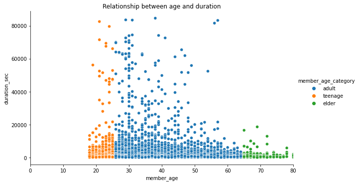

```python
# plt.figure(figsize=(20, 20))
ax = sb.relplot(data=df, x='member_age', y='duration_sec', aspect=1.7,hue='member_age_category')
plt.xlim(0, 80);
plt.title('Relationship between age and duration');
```

## Proportions of bike share for all trip per member age category

The huge majority of members are against bike share for all the trip.

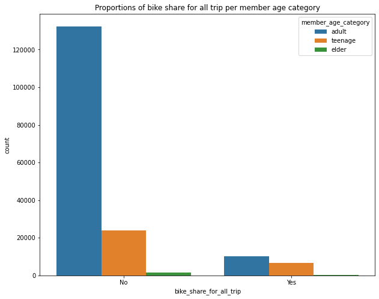

```python
plt.figure(figsize=(10, 8))
ax = sb.countplot(data=df, x='bike_share_for_all_trip',
                  hue='member_age_category',)
plt.title('Proportions of bike share for all trip per member age category');
```

```python
!jupyter nbconvert Part_II_slide_deck_template.ipynb --to slides --post serve --no-input --no-prompt
```

[output not shown]